# BankMarketing

## II - The Problem

The task is to analyze the dataset of customers provided by the banking institution, and determine what combination of personal characteristics and external factors are associated with the highest likelihood of the client subscribing to a term deposit.

Ascertaining which factors are most correlated with subscribing to term deposits will allow the bank to save time and money by focusing on clients that are likely to subscribe, and avoiding those that are not.

## III - Review of Related Literature

There were few Marketing Analysis happened with this bank marketing data set and based upon the usage of various exploration, prediction techniques and hyper parameter optimization, different analysis came with different conclusion and Recommendation. As per the Journal of Visualization and Analysis in bank Direct marketing prediction by Alaa abu-srhan, based on the exploratory data analysis , different oversampling methods such as Synthetic Minority Oversampling technique, Random Over Oversampling Technique, Selective Pre-processing, etc are used to overcome the imbalance in the response variable which in turn increase prediction accuracy from various classification prediction techniques. Following are the classification techniques,(Random forest, support vector machine (SVM), neural network (NN), Naive Bayes,and k-nearest neighbor (KNN) classifiers), are used for the analysis and the results are compared on Gmean and accuracy evaluation metrics to identify the best results.As per the conclusion, SVM and Naive Bayes Classifier provides a better accuracy and Gmean values.

Similarly in Data Mining- Bank Marketing Data set by “Kinga Włodarczyk”, Different classifier Techniques such as KNN, Linear and logistic regression models have created using different dependent variables in order to predict the response by comparing the accuracy.

In this analysis we are also going to try different classification techniques such as logistic regression, random forest, support vector machines with different hyper parameters and different predictors and compare the results based on the accuracy in order to identify the appropriate model.

## IV - Methodology

Read data and check for missing values As is outlined in the case, “duration” serves no predictive purpose, because it can only be known after the call is made, and can’t be used in the decision for which customer to call, so it is removed. Also removed is the pdays variable which lacks sufficient variance to provide meaningful predictive value.

Finally numeric data is normally scaled in order to condense the dimension space for calculating support vectors.

The data also needs to be balanced, because with the unmodified dataset, a classifier could achieve 90% accuracy by predicting a ‘no’ response for every observation.

Upsampling changes y variable name to Class.

First get an idea of most important variables using stepwise feature selection using AIC

Test several models (logistic regression, decision tree, random forest, linear SVC) using bootstrapped cross validation to optimize tuning variables

## V - Data

```r
set.seed(12345)
bank<-read.csv('bank-additional.csv',sep=";",stringsAsFactors = T)
sum(is.na(bank))
```

```
## [1] 0
```

```r
#duration in column 11
bank<-bank[-11]

#replace month abbreviations with numbers
monthord<-as.character(bank$month)
mn<-c('jan','feb','mar','apr','may','jun','jul',
  'aug','sep','oct','nov','dec')
md<-c(1,2,3,4,5,6,7,8,9,10,11,12)
monthord[monthord %in% mn] <- md[match(monthord, mn)]
bank$month<-as.factor(monthord)

#replace day of week abbreviations with numbers
weekord<-as.character(bank$day_of_week)
mn<-c('mon','tue','wed','thu','fri','sat','sun')
md<-c(1,2,3,4,5,6,7)
weekord[weekord %in% mn] <- md[match(weekord, mn)]
bank$day_of_week<-as.factor(weekord)

#reverse levels so "yes" is returned as the positive class to the caret model
bank$y <- factor(bank$y, levels=rev(levels(bank$y)))

#scale and remove variables with near-zero variance(which turns out to be pdays)
params<-preProcess(bank,method=c("scale","nzv"))
scaledbank<-predict(params,bank)

head(scaledbank)
```

```
##        age         job marital         education default housing    loan
## 1 2.908848 blue-collar married          basic.9y      no     yes      no
## 2 3.781502    services  single       high.school      no      no      no
## 3 2.424040    services married       high.school      no     yes      no
## 4 3.684541    services married          basic.9y      no unknown unknown
## 5 4.557195      admin. married university.degree      no     yes      no
## 6 3.102771    services  single university.degree      no      no      no
##     contact month day_of_week  campaign previous    poutcome emp.var.rate
## 1  cellular     5           5 0.7787679 0.000000 nonexistent  -1.15154715
## 2 telephone     5           5 1.5575358 0.000000 nonexistent   0.70372326
## 3 telephone     6           3 0.3893840 0.000000 nonexistent   0.89564778
## 4 telephone     6           5 1.1681519 0.000000 nonexistent   0.89564778
## 5  cellular    11           1 0.3893840 0.000000 nonexistent  -0.06397484
## 6  cellular     9           4 1.1681519 3.691479     failure  -0.70372326
##   cons.price.idx cons.conf.idx euribor3m nr.employed  y
## 1       160.3404    -10.055332 0.7573873    69.21739 no
## 2       162.2408     -7.922382 2.8005449    70.46488 no
## 3       163.0538     -9.097681 2.8622665    70.96849 no
## 4       163.0538     -9.097681 2.8605359    70.96849 no
## 5       160.8703     -9.141210 2.4175249    70.53004 no
## 6       162.5946     -8.161795 0.5099241    67.37805 no
```

```r
train<-sample(nrow(scaledbank),0.7*nrow(scaledbank))
banktrain<-scaledbank[train,]
banktest<-scaledbank[-train,]

banktrain<-upSample(x=banktrain[,-ncol(banktrain)],y=banktrain$y)
```

```r
fullmodel<-glm(Class~.,banktrain,family=binomial)
stepped<-stepAIC(fullmodel, direction = "both",trace = FALSE)

idx <- order(coef(summary(stepped))[,4])
out <- coef(summary(stepped))[idx,]
head(out,15)
```

```
##                        Estimate  Std. Error   z value     Pr(>|z|)
## poutcomesuccess      -2.0788136  0.22149155 -9.385521 6.260627e-21
## cons.conf.idx        -0.3969843  0.05400436 -7.350967 1.967779e-13
## contacttelephone      1.1159471  0.16178292  6.897806 5.281198e-12
## month3               -2.7813705  0.42635458 -6.523609 6.863558e-11
## jobmanagement         0.9710234  0.16270282  5.968080 2.400618e-09
## campaign              0.3068188  0.05282054  5.808703 6.295858e-09
## cons.price.idx       -1.3929925  0.27003108 -5.158638 2.487531e-07
## emp.var.rate          2.1737610  0.45715059  4.755022 1.984250e-06
## jobself-employed      0.9635472  0.22432101  4.295395 1.743829e-05
## age                  -0.1852449  0.04475575 -4.139019 3.487943e-05
## (Intercept)         267.3294841 64.69964957  4.131854 3.598495e-05
## day_of_week4          0.4357118  0.10766792  4.046811 5.192005e-05
## day_of_week2          0.4147762  0.10863476  3.818080 1.344944e-04
## poutcomenonexistent  -0.4292154  0.11874989 -3.614448 3.009877e-04
## day_of_week5          0.3902582  0.10992854  3.550108 3.850732e-04
```

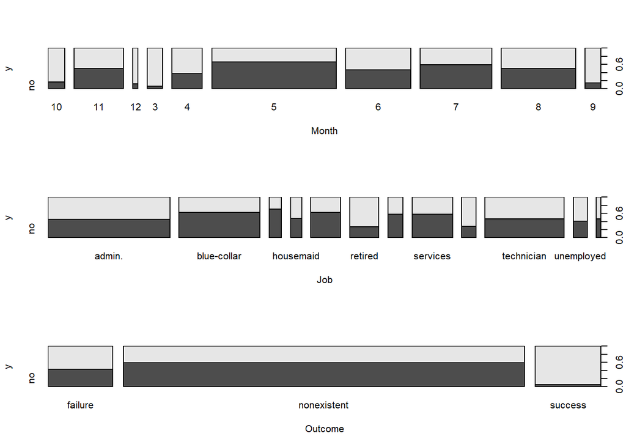

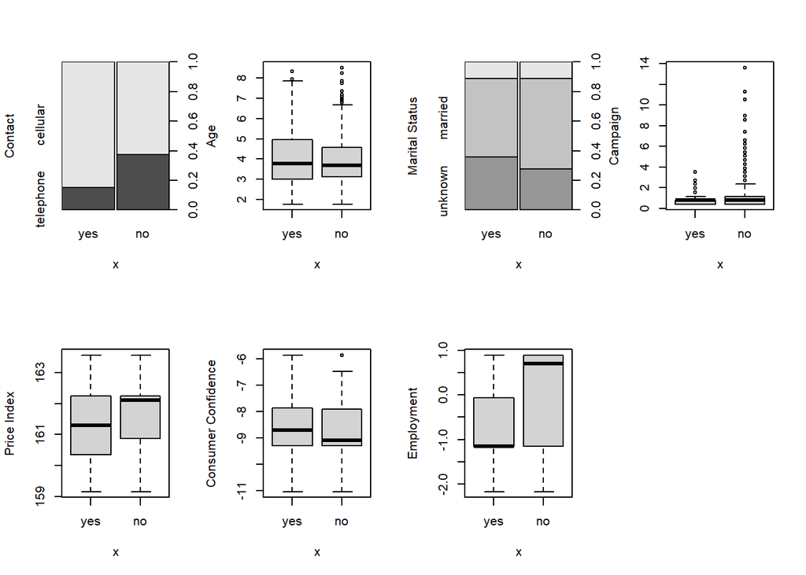

```r
TC <- trainControl(method = "boot", number=50,classProbs=TRUE,summaryFunction = twoClassSummary)

bankLOG <- train(Class~previous+contact+campaign+cons.price.idx+cons.conf.idx+emp.var.rate+education+day_of_week, data=banktrain,
                 method = "glmnet",
                 metric="Spec",
                 trControl = TC)
bankLOGfull <- train(Class~., data=banktrain,
                 method = "glmnet",
                 metric="Spec",
                 trControl = TC)




predlog<-predict(bankLOG,banktest)

predlogfull<-predict(bankLOGfull,banktest)

#Selected Model
confusionMatrix(predlog,banktest$y)
```

```
## Confusion Matrix and Statistics
##
##           Reference
## Prediction yes  no
##        yes  79 195
##        no   62 900
##
##                Accuracy : 0.7921
##                  95% CI : (0.7684, 0.8144)
##     No Information Rate : 0.8859
##     P-Value [Acc > NIR] : 1
##
##                   Kappa : 0.2709
##
##  Mcnemar's Test P-Value : <2e-16
##
##             Sensitivity : 0.56028
##             Specificity : 0.82192
##          Pos Pred Value : 0.28832
##          Neg Pred Value : 0.93555
##              Prevalence : 0.11408
##          Detection Rate : 0.06392
##    Detection Prevalence : 0.22168
##       Balanced Accuracy : 0.69110
##
##        'Positive' Class : yes
##
```

```r
#Full Model
confusionMatrix(predlogfull,banktest$y)
```

```
## Confusion Matrix and Statistics
##
##           Reference
## Prediction yes  no
##        yes  76 143
##        no   65 952
##
##                Accuracy : 0.8317
##                  95% CI : (0.8097, 0.8522)
##     No Information Rate : 0.8859
##     P-Value [Acc > NIR] : 1
##
##                   Kappa : 0.3291
##
##  Mcnemar's Test P-Value : 9.347e-08
##
##             Sensitivity : 0.53901
##             Specificity : 0.86941
##          Pos Pred Value : 0.34703
##          Neg Pred Value : 0.93609
##              Prevalence : 0.11408
##          Detection Rate : 0.06149
##    Detection Prevalence : 0.17718
##       Balanced Accuracy : 0.70421
##
##        'Positive' Class : yes
##
```

```r
TC <- trainControl(method = "boot", number=50,classProbs=TRUE,summaryFunction = twoClassSummary)
#TC <- trainControl(method="repeatedcv", number=10, repeats=3,classProbs=TRUE)


banktree=train(Class~.,data=banktrain, metric="ROC",trControl=TC,method='rpart',control = rpart.control(cp=0.1,minsplit = 15, minbucket = 6))



predtree<-predict(banktree,banktest)

#Decision Tree
confusionMatrix(predtree,banktest$y)
```

```
## Confusion Matrix and Statistics
##
##           Reference
## Prediction yes  no
##        yes  74 147
##        no   67 948
##
##                Accuracy : 0.8269
##                  95% CI : (0.8046, 0.8476)
##     No Information Rate : 0.8859
##     P-Value [Acc > NIR] : 1
##
##                   Kappa : 0.3132
##
##  Mcnemar's Test P-Value : 6.652e-08
##
##             Sensitivity : 0.52482
##             Specificity : 0.86575
##          Pos Pred Value : 0.33484
##          Neg Pred Value : 0.93399
##              Prevalence : 0.11408
##          Detection Rate : 0.05987
##    Detection Prevalence : 0.17880
##       Balanced Accuracy : 0.69529
##
##        'Positive' Class : yes
##
```

```r
TC <- trainControl(method="repeatedcv", number=10,repeats=3,
                   classProbs=TRUE,summaryFunction = twoClassSummary)

bankrad <- train(Class~poutcome+job+contact+campaign+month+cons.price.idx+cons.conf.idx+emp.var.rate, data=banktrain,
                 method = "svmLinear",
                 metric="ROC",
                 trControl = TC,
                 tuneGrid = expand.grid(C = seq(0.01, 2, length = 10)))

bankrad
```

```
## Support Vector Machines with Linear Kernel
##
## 5146 samples
##    8 predictor
##    2 classes: 'yes', 'no'
##
## No pre-processing
## Resampling: Cross-Validated (10 fold, repeated 3 times)
## Summary of sample sizes: 4632, 4630, 4632, 4631, 4630, 4632, ...
## Resampling results across tuning parameters:
##
##   C          ROC        Sens       Spec
##   0.0100000  0.7957970  0.6502111  0.8679778
##   0.2311111  0.8034600  0.6502111  0.8678486
##   0.4522222  0.8037690  0.6502111  0.8678486
##   0.6733333  0.8029302  0.6502111  0.8678486
##   0.8944444  0.8002942  0.6502111  0.8678486
##   1.1155556  0.7989997  0.6502111  0.8678486
##   1.3366667  0.7997276  0.6502111  0.8678486
##   1.5577778  0.8007366  0.6502111  0.8678486
##   1.7788889  0.8015729  0.6502111  0.8678486
##   2.0000000  0.7998314  0.6502111  0.8678486
##
## ROC was used to select the optimal model using the largest value.
## The final value used for the model was C = 0.4522222.
```

```r
predrad<-predict(bankrad,banktest)

#Linear SVM"
confusionMatrix(predrad,banktest$y)
```

```
## Confusion Matrix and Statistics
##
##           Reference
## Prediction yes  no
##        yes  75 153
##        no   66 942
##
##                Accuracy : 0.8228
##                  95% CI : (0.8004, 0.8437)
##     No Information Rate : 0.8859
##     P-Value [Acc > NIR] : 1
##
##                   Kappa : 0.3091
##
##  Mcnemar's Test P-Value : 6.197e-09
##
##             Sensitivity : 0.53191
##             Specificity : 0.86027
##          Pos Pred Value : 0.32895
##          Neg Pred Value : 0.93452
##              Prevalence : 0.11408
##          Detection Rate : 0.06068
##    Detection Prevalence : 0.18447
##       Balanced Accuracy : 0.69609
##
##        'Positive' Class : yes
##
```

```r
TC <- trainControl(method = "boot", number=50,classProbs=TRUE,summaryFunction = twoClassSummary)


bankrf <- train(Class~poutcome+job+loan+contact+campaign+month+cons.price.idx+cons.conf.idx+emp.var.rate+education+day_of_week, data=banktrain,
                 method = "rf",
                 metric="ROC",
                 trControl = TC)
bankrf
```

```
## Random Forest
##
## 5146 samples
##   11 predictor
##    2 classes: 'yes', 'no'
##
## No pre-processing
## Resampling: Bootstrapped (50 reps)
## Summary of sample sizes: 5146, 5146, 5146, 5146, 5146, 5146, ...
## Resampling results across tuning parameters:
##
##   mtry  ROC        Sens       Spec
##    2    0.8621587  0.6688784  0.8866025
##   21    0.9848371  0.9856103  0.8785685
##   40    0.9808097  0.9891454  0.8722856
##
## ROC was used to select the optimal model using the largest value.
## The final value used for the model was mtry = 21.
```

```r
predrf<-predict(bankrf,banktest)

#Random Forest
confusionMatrix(predrf,banktest$y)
```

```
## Confusion Matrix and Statistics
##
##           Reference
## Prediction yes  no
##        yes  40 110
##        no  101 985
##
##                Accuracy : 0.8293
##                  95% CI : (0.8071, 0.8499)
##     No Information Rate : 0.8859
##     P-Value [Acc > NIR] : 1.0000
##
##                   Kappa : 0.1783
##
##  Mcnemar's Test P-Value : 0.5818
##
##             Sensitivity : 0.28369
##             Specificity : 0.89954
##          Pos Pred Value : 0.26667
##          Neg Pred Value : 0.90700
##              Prevalence : 0.11408
##          Detection Rate : 0.03236
##    Detection Prevalence : 0.12136
##       Balanced Accuracy : 0.59162
##
##        'Positive' Class : yes
##
```

## VII - Conclusions

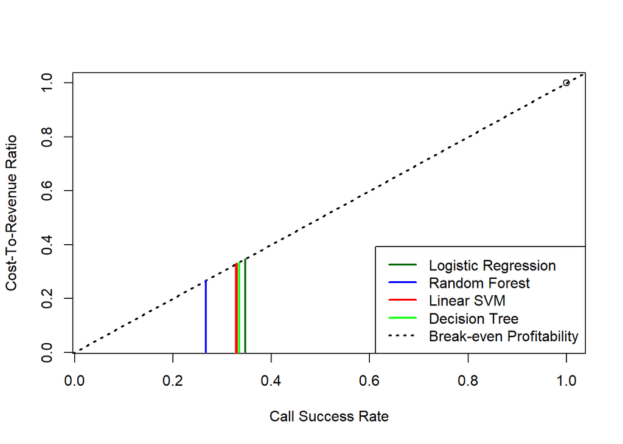

The decision tree has the added benefit of being clearly understandable when choosing who to call: Make the call if the nr.employed<69 or if the cons.conf.idx< -10

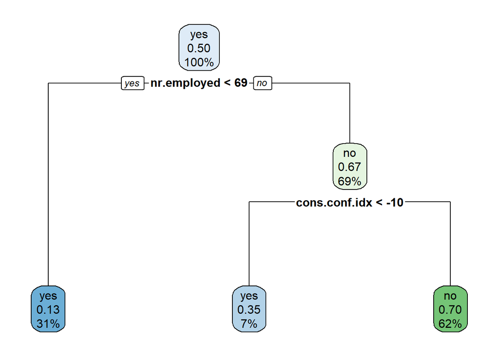